# Mixed models 1

Tutorial 10: exercises and solutions

Dr Massimiliano Canzi

## Setup

```r
library(tidyverse)
library(broom)
library(lme4)
library(simling)
```

## The data

`rt_frequency` comes from a small simulated lexical decision task: 10 participants decide for each of the same 20 words whether it is a word of their language. Half of the words are frequent and half are rare (`frequency`), and `rt` is the reaction time in ms.

```r
glimpse(rt_frequency)
```

```
Rows: 200
Columns: 5
$ participant <fct> P01, P01, P01, P01, P01, P01, P01, P01, P01, P01…
$ word        <fct> w01, w02, w03, w04, w05, w06, w07, w08, w09, w10…
$ frequency   <fct> high, high, high, high, high, high, high, high, …
$ rt          <dbl> 805, 887, 747, 624, 744, 558, 608, 522, 418, 757…
$ correct     <int> 1, 1, 1, 1, 1, 1, 1, 1, 1, 1, 1, 1, 0, 0, 1, 1, …
```

Today’s question: are rare words recognised more slowly?

# 1. Repeated measures

## 1.1 Who saw what?

Use `count()` to find out how many responses there are from each participant and for each word. Why are the 200 reaction times not 200 independent observations?

## 1.1 Solution

```r
rt_frequency |> count(participant)
```

```
# A tibble: 10 × 2
   participant     n
   <fct>       <int>
 1 P01            20
 2 P02            20
 3 P03            20
 4 P04            20
 5 P05            20
 6 P06            20
 7 P07            20
 8 P08            20
 9 P09            20
10 P10            20
```

## 1.1 Solution

```r
rt_frequency |> count(word)
```

```
# A tibble: 20 × 2
   word      n
   <fct> <int>
 1 w01      10
 2 w02      10
 3 w03      10
 4 w04      10
 5 w05      10
 6 w06      10
 7 w07      10
 8 w08      10
 9 w09      10
10 w10      10
# ℹ 10 more rows
```

Each participant gave 20 responses, and each word was seen 10 times. Responses from the same participant are alike, because some people are faster than others, and responses to the same word are alike, because some words are easier than others.

## 1.2 One panel per participant

Plot `rt` by `frequency` with `geom_boxplot()`, with one panel per participant (`facet_wrap(~ participant)`). Do all participants show the same pattern? Do they differ in other ways?

## 1.2 Solution

```r
rt_frequency |>
  ggplot(aes(x = frequency, y = rt)) +
  geom_boxplot(fill = "plum2") +
  facet_wrap(~ participant, nrow = 2) +
  xlab("Word frequency") + ylab("Reaction time (ms)")
```

## 1.2 Solution

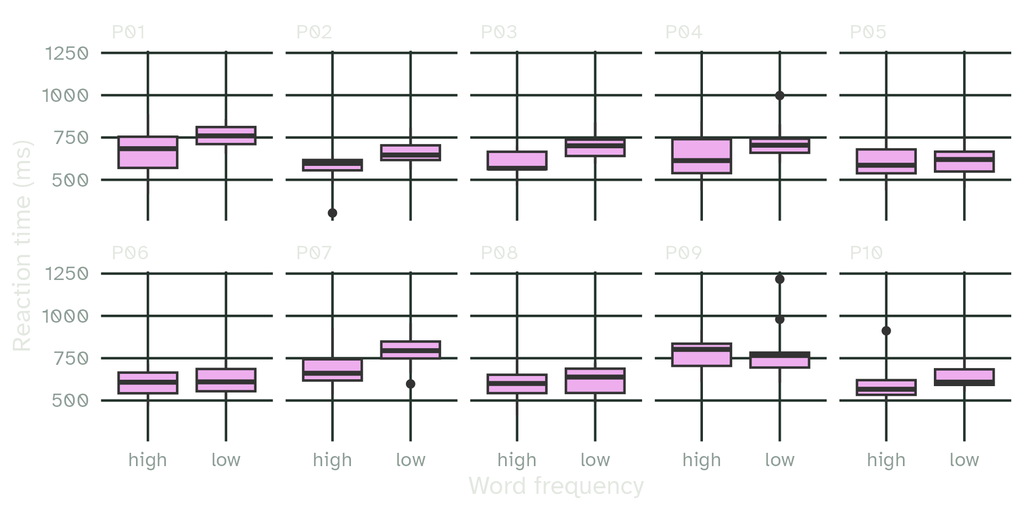

Most participants are slower with rare words. They also differ in their overall speed: some panels sit much higher than others.

## 1.3 A model that ignores the participants

Fit a linear model of `rt` as a function of `frequency` and look at it with `tidy()`. Note the estimate and the standard error of `frequencylow`.

## 1.3 Solution

```r
m_lm <- lm(rt ~ frequency, data = rt_frequency)
tidy(m_lm)
```

```
# A tibble: 2 × 5
  term         estimate std.error statistic   p.value
  <chr>           <dbl>     <dbl>     <dbl>     <dbl>
1 (Intercept)     631.       12.0     52.5  4.31e-118
2 frequencylow     61.8      17.0      3.63 3.55e-  4
```

Rare words take 62 ms longer, with a standard error of 17 ms. This model treats all 200 responses as independent.

# 2. A mixed model

## 2.1 Varying intercepts

Fit a mixed model with `lmer()`: `rt` as a function of `frequency`, with varying intercepts for participants and for words. Print the fixed effects with `fixef()`. Compare them with the coefficients of `m_lm`.

## 2.1 Solution

```r
m <- lmer(rt ~ frequency + (1 | participant) + (1 | word), data = rt_frequency)
fixef(m)
```

```
 (Intercept) frequencylow
      630.86        61.82
```

The fixed effects are the same as the coefficients of `m_lm`, because every participant saw every word.

## 2.2 More uncertainty

Compare the standard error of `frequencylow` in `m` (`summary(m)$coefficients`) with the one in `m_lm`. Why is it larger?

## 2.2 Solution

```r
summary(m)$coefficients
```

```
             Estimate Std. Error   t value
(Intercept)    630.86   26.56235 23.750154
frequencylow    61.82   26.00113  2.377589
```

The standard error grows from 17 to 26 ms. The frequency effect rests on only 20 words, 10 frequent and 10 rare, and words differ a lot. `m_lm` ignores this and is too sure of itself.

## 2.3 The random effects

Look at the standard deviations of the random effects with `VarCorr(m)`. Say in words what each of the three numbers means.

## 2.3 Solution

```r
VarCorr(m)
```

```
 Groups      Name        Std.Dev.
 word        (Intercept) 49.947
 participant (Intercept) 60.624
 Residual                94.106
```

Words differ in how fast they are recognised, with an SD of about 50 ms around the mean of their frequency group (`word`). Participants differ in their overall speed, with an SD of about 61 ms (`participant`). What is left over from one trial to the next, the `Residual`, has an SD of about 94 ms.

## 2.4 Bonus: varying slopes

Fit the model again with varying slopes for frequency by participant: `(1 + frequency | participant)`. Look at `VarCorr()` and at `isSingular()`. What is odd about the correlation? And why can the model not have varying frequency slopes by word?

## 2.4 Solution

```r
m_slopes <- lmer(rt ~ frequency + (1 + frequency | participant) + (1 | word), data = rt_frequency)
VarCorr(m_slopes)
```

```
 Groups      Name         Std.Dev. Corr
 word        (Intercept)  49.988
 participant (Intercept)  54.441
             frequencylow 12.406   1.000
 Residual                 93.889
```

```r
isSingular(m_slopes)
```

```
[1] TRUE
```

The correlation between the intercepts and the slopes is exactly 1, and the fit is singular: `lmer()` reports “boundary (singular) fit”. With only 10 participants, the model cannot tell how much their frequency effects really differ. In the simulation they do not differ at all (`?rt_frequency`), so `(1 | participant)` is enough here.

Each word is either frequent or rare, so there is no frequency effect within a word that could vary between words.

# 3. Weekly assignment

Exercises 3.1 to 3.3 are this week’s assignment. Complete them at home, in a file started from the konstats template “Weekly assignment” (tutorial 1), and hand in the .Rmd file within a week.

In `dgs_iconicity`, 30 deaf signers of German Sign Language and 30 hearing non-signers (`group`) each rate the same 300 signs for iconicity, from 1 (not iconic) to 7 (very iconic). `rater` and `sign` identify the raters and the signs.

## 3.1 The design

How many ratings are there from each rater, and for each sign? Compute the mean `rating` of each group.

## 3.2 A mixed model

Fit a mixed model of `rating` as a function of `group`, with varying intercepts for raters and for signs. Report the difference between the groups in a sentence, and say what the SD of each random effect means.

## 3.3 Which varying slope?

Could the model have a varying slope for `group` by rater? By sign? Explain your answer in one or two sentences, and fit the model with the varying slope that is possible. Does the difference between the groups change?

## Reading

This tutorial goes with chapter 14 of Winter (2019).

Winter, B. (2019). *Statistics for linguists: An introduction using R*. Routledge. https://doi.org/10.4324/9781315165547

## Slides and exercises

[figure not shown]

These slides

mcanzi.de/statistics/tutorials/10_mixed_models_1.html

Exercise sheet (R Markdown)

mcanzi.de/statistics/tutorials/10_mixed_models_1.Rmd